# genetic distance measures

Rather than rely on heterozygosity, my committee wanted to see the genetic distance between atrovirens and the other 53 species.

I used MEGA to generate distance measures using a variety of models from the aligned sequence data and will compare those models here.

```r
library(tidyverse)
dist <- read_csv("~/Desktop/Chapter3_sppID/sebastes_genetic_distance_summary.csv")
# group by model
dist1 <- dist %>%
  group_by(model_type) %>%
  rename(Model = model_type)
```

plot the different models

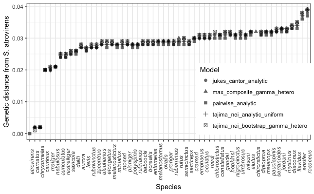

```r
dist_plot <- ggplot(dist1, aes(x = fct_reorder(species, genetic_distance, .desc = FALSE), y = genetic_distance, shape = Model)) +
  geom_point(size = 2, alpha = 0.6) +
  theme_bw() +
  xlab("Species") +
  ylab("Genetic distance from S. atrovirens")
dist_plot +
  theme(
    axis.text.x = element_text(angle = 90, face = "italic"),
    legend.position = c(0.8, 0.3)
  )
ggsave("pdf_outputs/genetic_distance_plot.pdf", height = 6, width = 8)
```

Another question is whether this genetic distance is consistent with the heterozygosity rank.

I can read in the int_hz data and stick that onto the genetic distance data frame

```r
hz <- read_csv("csv_outputs/filtered_int_hz.csv")
hz2 <- hz %>%
  group_by(collection) %>%
  summarise(hz = mean(fract_hz)) %>%
  rename(species = collection)
```

Stick that info onto the dataframe

```r
dist_hz <- dist %>%
  left_join(., hz2)
dist_hz
```

| species | model_type | genetic_distance | hz |
| --- | --- | --- | --- |
| atrovirens | pairwise_analytic | 0.000 | 0.45781055 |
| carnatus | pairwise_analytic | 0.002 | 0.40317897 |
| chrysomelas | pairwise_analytic | 0.002 | 0.40858692 |
| melanops | pairwise_analytic | 0.031 | 0.10210306 |
| flavidus | pairwise_analytic | 0.033 | 0.11886248 |
| serranoides | pairwise_analytic | 0.032 | 0.06430668 |
| rosaceus | pairwise_analytic | 0.037 | 0.22752919 |
| ensifer | pairwise_analytic | 0.036 | 0.23618045 |
| jordani | pairwise_analytic | 0.032 | 0.09560823 |
| alutus | pairwise_analytic | 0.031 | 0.10381997 |

[output cut: 256 more lines]

plotting it is non-trivial because ggplot intentionally makes this challenging

## Plot genetic distance vs. hz (and nucleotide diversity)

Similar to in previous exercises, I want to change the factor levels to correspond to phylogenetic relationships.

I want to set the species phylogenetically rather than alphabetically:

[figure not shown]

```r
# set the levels explicitly
dist_hz$species <- factor(dist_hz$species, levels = c("chrysomelas", "carnatus", "caurinus", "maliger", "nebulosus", "dallii","rastrelliger", "auriculatus", "saxicola", "semicinctus", "elongatus", "miniatus", "pinniger", "oculatus", "constellatus", "umbrosus", "rosaceus", "chlorostictus", "ensifer", "babcocki", "nigrocinctus", "rubrivinctus", "serriceps", "rufus", "ovalis", "hopkinsi", "rufinanus", "moseri", "jordani", "paucispinis", "goodei", "levis", "entomelas", "mystinus", "diaconus", "flavidus", "serranoides", "melanops", "ruberrimus", "aurora", "diploproa", "melanostomus", "reedi", "crameri", "polyspinis", "alutus", "melanostictus", "aleutianus", "emphaeus", "wilsoni", "zacentrus", "proriger", "borealis"))
# colors
mycol <- colorRampPalette(c("palegreen", "darkolivegreen", "darkslategrey", "darkgreen", "deepskyblue", "aquamarine4", "seagreen4", "cadetblue", "cyan", "darkblue", "midnightblue", "blue", "dodgerblue", "darkcyan", "darkslateblue", "slateblue", "steelblue4", "skyblue", "paleturquoise4", "brown", "royalblue", "purple4", "orange", "darkorange", "darkgoldenrod", "chocolate", "tan4", "saddlebrown", "sienna", "navajowhite4", "darkgray", "black"))(54)
dist_hz %>%
  filter(model_type == "pairwise_analytic") %>%
  ggplot(aes(x = genetic_distance, y = hz, color = species)) +
  geom_point() +
  theme_bw() +
  scale_color_manual(values = mycol) +
  xlab("Genetic distance") +
  ylab("Heterozygosity")
ggsave("pdf_outputs/dist_vs_hz.pdf", width = 9, height = 5)
```

Try using pegas to get at nucleotide diversity

Use hierfstat

```r
dataset1 <- read.genepop("../new_baseline_data/processed/sebastes_final_dataset.gen", ncode = 3)
```

```
 Converting data from a Genepop .gen file to a genind object...


File description:  Title line:"997_samples_genepop2d"
```

```
Duplicate individual names detected. Coercing them to be unique.
```

```
...done.
```

```r
# set population as a factor
dataset1@pop <- as.factor(dataset1@pop)
```

[output not shown]

[output cut: 80 more lines]

```r
rock_he %>%
  na_if("NaN") %>%
  na_if("-Inf") %>%
  select(-Locus) %>%
  colMeans(., na.rm = TRUE)
```

```
   atrovirens   chrysomelas      carnatus      caurinus       maliger
  0.466788889   0.435733333   0.416388889   0.194955556   0.296277778
    nebulosus        dallii  rastrelliger   auriculatus      saxicola
  0.138568182   0.108797753   0.054573034   0.042200000   0.063397727
  semicinctus     elongatus      miniatus      pinniger      oculatus
  0.083662921   0.100418605   0.087494253   0.061298851   0.086581395
 constellatus      umbrosus      rosaceus chlorostictus       ensifer
  0.130635294   0.166738636   0.242534091   0.185953488   0.257162791
     babcocki  nigrocinctus  rubrivinctus     serriceps         rufus
  0.050372093   0.097892857  -0.019951220  -0.021738095   0.069709302
       ovalis      hopkinsi     rufinanus        moseri       jordani
  0.051686047   0.082280899  -0.335616438  -0.119602564   0.061654321
  paucispinis        goodei         levis     entomelas      mystinus
  0.025837500   0.059986667   0.019170455   0.048571429   0.123951220
     diaconus      flavidus   serranoides      melanops    ruberrimus
  0.094987805   0.121626506   0.069282051   0.105795455   0.063773810
       aurora     diploproa  melanostomus         reedi       crameri
  0.054302326   0.130639535   0.063747126  -0.011641975   0.026148148
   polyspinis        alutus melanostictus    aleutianus      emphaeus
 -0.003833333   0.106857143   0.134439024   0.094182927   0.109879518
      wilsoni     zacentrus      proriger      borealis
  0.128709302   0.068977011   0.068573034   0.006542169
```

Those look a little bit wonky, namely, the negative expected heterozygosity…

## UPDATE: 8 JULY 2019

Here I will modify the previous figure from my dissertation that plotted heterozygosity vs. genetic distance and replace that with nucleotide diversity vs. genetic distance.

Nucleotide diversity was calculated as –sites-pi in vcftools, I summed the values from –sites-pi for each species, and then divided that number by the total number of sites (11,368) in the 96 loci. As far as I can tell, this properly accounts for the invariant sites which are otherwise not included by vcftools. The coverage at the invariant sites is not a necessary part of the calculation (at least according to some of what I’ve read).

The details are in `16-nucleotide-diversity.Rmd`

Read in that file here:

```r
pi <- read_csv("csv_outputs/nucleotide_diversity.csv")
```

and the file with genetic distance:

```r
dist <- read_csv("~/Desktop/Chapter3_sppID/sebastes_genetic_distance_summary.csv")
# Stick that info onto the dataframe
dist_pi <- dist %>%
  left_join(., pi)
dist_pi %>%
  filter(model_type == "pairwise_analytic")
```

| species | model_type | genetic_distance | nuc_diversity |
| --- | --- | --- | --- |
| atrovirens | pairwise_analytic | 0.000 | 0.0067804192 |
| carnatus | pairwise_analytic | 0.002 | 0.0056091117 |
| chrysomelas | pairwise_analytic | 0.002 | 0.0059204394 |
| melanops | pairwise_analytic | 0.031 | 0.0022337650 |
| flavidus | pairwise_analytic | 0.033 | 0.0018945069 |
| serranoides | pairwise_analytic | 0.032 | 0.0009965578 |
| rosaceus | pairwise_analytic | 0.037 | 0.0046720945 |
| ensifer | pairwise_analytic | 0.036 | 0.0039266965 |
| jordani | pairwise_analytic | 0.032 | 0.0030755832 |
| alutus | pairwise_analytic | 0.031 | 0.0025582737 |

[output cut: 44 more lines]

plotting it is non-trivial because ggplot intentionally makes this challenging

## Plot genetic distance vs. nucleotide diversity

Similar to in previous exercises, I want to change the factor levels to correspond to phylogenetic relationships.

I want to set the species phylogenetically rather than alphabetically:

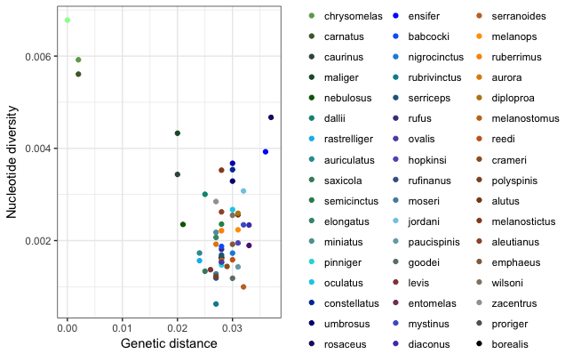

```r
# set the levels explicitly
dist_pi$species <- factor(dist_pi$species, levels = c("atrovirens", "chrysomelas", "carnatus", "caurinus", "maliger", "nebulosus", "dallii","rastrelliger", "auriculatus", "saxicola", "semicinctus", "elongatus", "miniatus", "pinniger", "oculatus", "constellatus", "umbrosus", "rosaceus", "chlorostictus", "ensifer", "babcocki", "nigrocinctus", "rubrivinctus", "serriceps", "rufus", "ovalis", "hopkinsi", "rufinanus", "moseri", "jordani", "paucispinis", "goodei", "levis", "entomelas", "mystinus", "diaconus", "flavidus", "serranoides", "melanops", "ruberrimus", "aurora", "diploproa", "melanostomus", "reedi", "crameri", "polyspinis", "alutus", "melanostictus", "aleutianus", "emphaeus", "wilsoni", "zacentrus", "proriger", "borealis"))
# colors
mycol <- colorRampPalette(c("palegreen", "darkolivegreen", "darkslategrey", "darkgreen", "deepskyblue", "aquamarine4", "seagreen4", "cadetblue", "cyan", "darkblue", "midnightblue", "blue", "dodgerblue", "darkcyan", "darkslateblue", "slateblue", "steelblue4", "skyblue", "paleturquoise4", "brown", "royalblue", "purple4", "orange", "darkorange", "darkgoldenrod", "chocolate", "tan4", "saddlebrown", "sienna", "navajowhite4", "darkgray", "black"))(54)
dist_pi %>%
  filter(model_type == "pairwise_analytic") %>%
  ggplot(aes(x = genetic_distance, y = nuc_diversity, color = species)) +
  geom_point() +
  theme_bw() +
  scale_color_manual(values = mycol) +
  xlab("Genetic distance") +
  ylab("Nucleotide diversity")
```

```r
#ggsave("pdf_outputs/dist_vs_hz.pdf", width = 9, height = 5)
```

Okay, now switch the color scheme to subgenera rather than species:

Make a list of subgenera and species and read that in

```r
subgenera <- read_csv("../data/sebastes_subgenera.csv")
```

```r
# join expected Hz and genetic distance
dist_pi2 <- dist_pi %>%
  left_join(., subgenera)
```

```
Column `species` joining factor and character vector, coercing into character vector
```

```r
# and set the levels
dist_pi2$subgenus <- factor(dist_pi2$subgenus, levels = c("Pteropodus", "Auctospina", "Allosebastes", "Hispaniscus", "Rosicola", "Sebastomus", "Sebastichthys", "Sebastocarus", "Acutomentum", "Sebastodes", "Sebastosomus", "Sebastopyr", "Eosebastes", "Zalopyr", "unclassified"))
levels(dist_pi2$subgenus)
```

```
 [1] "Pteropodus"    "Auctospina"    "Allosebastes"  "Hispaniscus"   "Rosicola"
 [6] "Sebastomus"    "Sebastichthys" "Sebastocarus"  "Acutomentum"   "Sebastodes"
[11] "Sebastosomus"  "Sebastopyr"    "Eosebastes"    "Zalopyr"       "unclassified"
```

Change the colors:

```r
library(RColorBrewer)
# subgenera colors
#mycolors = colorRampPalette(brewer.pal(name="Accent", n = 8))(15)
mycolors = c("darkgreen", "dodgerblue", "darkblue", "chartreuse", "aquamarine", "deeppink", "firebrick4", "orchid", "purple4", "orange", "orangered", "saddlebrown", "navajowhite4", "darkgray", "black")

# species colors
mycol <- colorRampPalette(c("palegreen", "darkolivegreen", "darkslategrey", "darkgreen", "deepskyblue", "aquamarine4", "seagreen4", "cadetblue", "cyan", "darkblue", "midnightblue", "blue", "dodgerblue", "darkcyan", "darkslateblue", "slateblue", "steelblue4", "skyblue", "paleturquoise4", "brown", "royalblue", "purple4", "orange", "darkorange", "darkgoldenrod", "chocolate", "tan4", "saddlebrown", "sienna", "navajowhite4", "darkgray", "black"))(54)
```

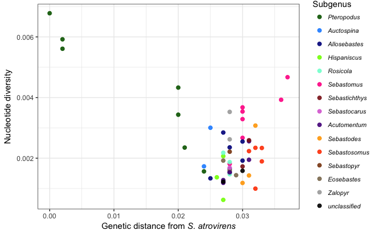

```r
# italicize atrovirens in the axis title
my_x_title <- expression(paste("Genetic distance from ", italic("S. atrovirens")))
# plot
d2 <- dist_pi2 %>%
  filter(model_type == "pairwise_analytic") %>%
  ggplot(aes(x = genetic_distance, y = nuc_diversity, color = subgenus)) +
  geom_point(size = 2, alpha = 0.9) +
  theme_bw() +
  scale_color_manual(values = mycolors) +
  xlab(my_x_title) +
  ylab("Nucleotide diversity")
d2 + theme(
  legend.text = element_text(size = 8, face = "italic")) +
  guides(color = guide_legend(title="Subgenus"))
```

```r
# save that plot
# ggsave("pdf_outputs/subgenera_genetic_distance_v_nucleotide_diversity.pdf", width = 7, height = 5)
```

Try adding a trend line?

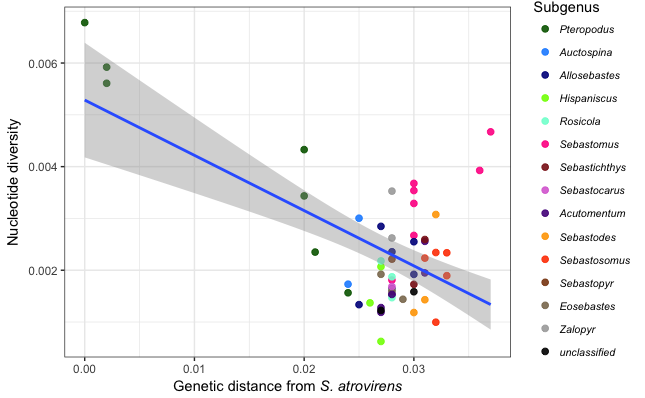

```r
d2 <- dist_pi2 %>%
  ungroup() %>%
  filter(model_type == "pairwise_analytic") %>%
  ggplot() +
  geom_point(aes(x = genetic_distance, y = nuc_diversity, color = subgenus),
             size = 2, alpha = 0.9) +
  geom_smooth(aes(x = genetic_distance, y = nuc_diversity), method = lm, se=TRUE) +
  theme_bw() +
  scale_color_manual(values = mycolors) +
  xlab(my_x_title) +
  ylab("Nucleotide diversity")
d2 + theme(
  legend.text = element_text(size = 8, face = "italic")) +
  guides(color = guide_legend(title="Subgenus"))
```

```r
# add a regression line?
# lm_eqn <- function(df){
#     m <- lm(y ~ x, df);
#     eq <- substitute(italic(y) == a + b %.% italic(x)*","~~italic(r)^2~"="~r2,
#          list(a = format(unname(coef(m)[1]), digits = 2),
#               b = format(unname(coef(m)[2]), digits = 2),
#              r2 = format(summary(m)$r.squared, digits = 3)))
#     as.character(as.expression(eq));
# }
#
# p + geom_text(x = 25, y = 300, label = lm_eqn(df), parse = TRUE)
```

| species | genetic_distance | nuc_diversity | subgenus | Li_etal |
| --- | --- | --- | --- | --- |
| rosaceus | 0.037 | 0.004672095 | Sebastomus | Sebastomus |
| ensifer | 0.036 | 0.003926697 | Sebastomus | Sebastomus |
| chlorostictus | 0.030 | 0.003676180 | Sebastomus | Sebastomus |
| umbrosus | 0.030 | 0.003289380 | Sebastomus | Sebastomus |
| constellatus | 0.030 | 0.003538158 | Sebastomus | Sebastomus |
| oculatus | 0.030 | 0.002671800 | Sebastomus | Sebastomus |
| rufus | 0.028 | 0.001811113 | Sebastomus | Acutomentum |